# Exercise_4.9_Part 2

### Step 1 : Impoting the necessary analysis and visualization libraries, then importing the most up-to-date project data

```python
# Import libraries
import pandas as pd
import numpy as np
import os
import matplotlib.pyplot as plt
import seaborn as sns
import scipy
```

```python
# Import most up-to-date project data
path = r'C:\Users\Bilel\Desktop\data_analyst_Carrer Foundry\Data Immersion\07-12-24 Instacart Basket Analysis'
df =pd.read_pickle(os.path.join(path,'02 Data', 'Prepared Data', 'orders_products_customers_merged.pkl'))
```

### Step 2 : create a bar chart, a histogram, a scatterplot, and a line chart, using a sample subset for the line chart

Already done in the Exercise Notebook

### Step 3: histogram of the “order_hour_of_day” column.

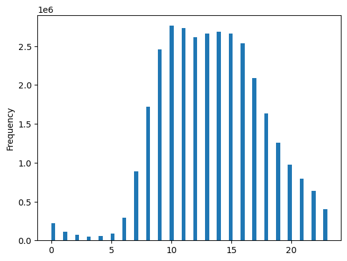

```python
hist = df['order_hour_of_day'].plot.hist(bins=70)
```

This histogram shows that most purchases are between 9am and 5pm

### Step 4 : Create a bar chart from the "loyalty_flag" column

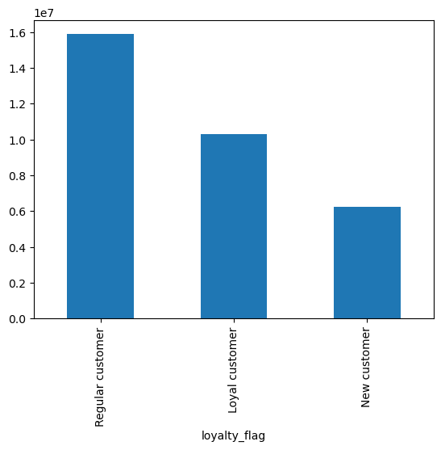

```python
bar = df ['loyalty_flag'].value_counts().plot.bar()
```

### Step 5: Checking the difference in expenditure depending on the hour of the day

#### 5.1: Sampling Data

```python
#Spliting dataframe in two sapmles with the same distribution (split 70/30)
np.random.seed (4)
```

```python
#Create a list holding True/False values to the test np.random.rand()
dev = np.random.rand(len(df))<=0.7
```

```python
# store 70% of the sample in the dataframe big
big = df[dev]
```

```python
# store 30% of the sample in the dataframe small
small =  df[~dev]
```

```python
#verification
len(df)
```

```
32404859
```

```python
len(big)+ len (small)
```

```
32404859
```

#### 5.2: Create Line chart

```python
#reducing number of columns to reduce plotting time
df_2 = small[['order_hour_of_day', 'prices']]
```

```python
# Check if the subset of the sample was made properly
df_2.head(5)
```

|  | order_hour_of_day | prices |
| --- | --- | --- |
| 0 | 8 | 9.0 |
| 2 | 8 | 4.4 |
| 3 | 8 | 4.7 |
| 6 | 7 | 3.0 |
| 10 | 7 | 4.0 |

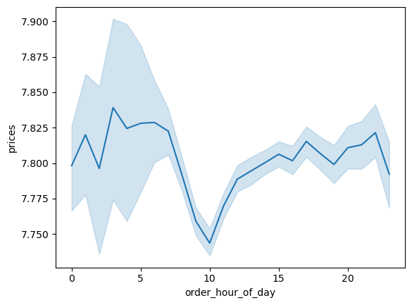

```python
# Create a line chart
line = sns.lineplot(data = df_2, x = 'order_hour_of_day',y = 'prices')
```

### Step 6: Create a line chart exploring the connections between age and number of dependents

```python
df.head()
```

|  | order_id | user_id | order_number | orders_day_of_week | order_hour_of_day | days_since_prior_order | new_customer | product_id | add_to_cart_order | reordered | ... | order_frequency_flag | first_name | last_name | gender | state | age | date_joined | number_of_dependants | family_status | income |
| --- | --- | --- | --- | --- | --- | --- | --- | --- | --- | --- | --- | --- | --- | --- | --- | --- | --- | --- | --- | --- | --- |
| 0 | 2539329 | 1 | 1 | 2 | 8 | NaN | True | 196 | 1 | 0 | ... | Non_frequent customer | Linda | Nguyen | Female | Alabama | 31 | 2/17/2019 | 3 | married | 40423 |
| 1 | 2539329 | 1 | 1 | 2 | 8 | NaN | True | 14084 | 2 | 0 | ... | Non_frequent customer | Linda | Nguyen | Female | Alabama | 31 | 2/17/2019 | 3 | married | 40423 |
| 2 | 2539329 | 1 | 1 | 2 | 8 | NaN | True | 12427 | 3 | 0 | ... | Non_frequent customer | Linda | Nguyen | Female | Alabama | 31 | 2/17/2019 | 3 | married | 40423 |
| 3 | 2539329 | 1 | 1 | 2 | 8 | NaN | True | 26088 | 4 | 0 | ... | Non_frequent customer | Linda | Nguyen | Female | Alabama | 31 | 2/17/2019 | 3 | married | 40423 |
| 4 | 2539329 | 1 | 1 | 2 | 8 | NaN | True | 26405 | 5 | 0 | ... | Non_frequent customer | Linda | Nguyen | Female | Alabama | 31 | 2/17/2019 | 3 | married | 40423 |

5 rows × 33 columns

```python
# defining smaller df using the same 30% subset sample
df_3 = small[['age', 'number_of_dependants']]
```

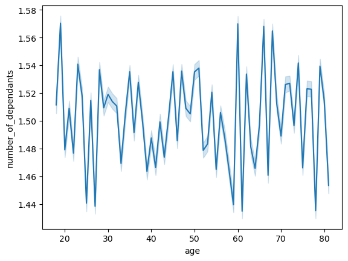

```python
line_2= sns.lineplot(data = df_3, x = 'age',y = 'number_of_dependants')
```

The line chart shows a fluctuating relationship between customer age and the number of dependents, with no clear trend. This indicates that a one-size-fits-all marketing approach may not be effective. Instead, consider tailoring campaigns to specific age groups and using detailed customer data to personalize marketing strategies, especially for age groups in their 50s and 60s, which show higher variability. This approach will help address the unique family dynamics of each segment, leading to more effective marketing outcomes.

### Step 7: Create a scatterplot of age vs income

```python
# defining smaller df using the same 30% subset sample
df_4 = small[['age', 'income']]
```

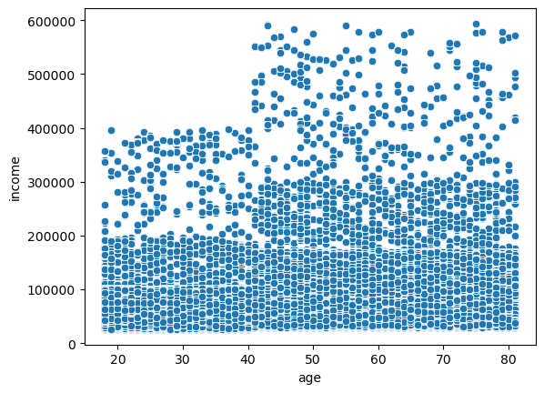

```python
#Create a scatterplot
scatterplot = sns.scatterplot(x = 'age', y = 'income',data = df_4)
```

### Step 8: Export visualizations

```python
hist.figure.savefig(os.path.join(path, '04 Analysis','Visualizations', 'hist_order_hour_of_day_frequency.png'))
```

```python
bar.figure.savefig(os.path.join(path, '04 Analysis','Visualizations', 'loyalty_flag_distribution.png'))
```

```python
line.figure.savefig(os.path.join(path, '04 Analysis','Visualizations', 'expenditure_depending_on_hour_of_day.png'))
```

```python
line_2.figure.savefig(os.path.join(path, '04 Analysis','Visualizations', 'connections_age_and_number_of_dependents.png'))
```

```python
scatterplot.figure.savefig(os.path.join(path, '04 Analysis','Visualizations', 'age_vs_income.png'))
```